# Two-way Mundlak (TWM), Extended TWFE regression

Author

Shunkei Kakimoto

# 1 Overview of Wooldridge (2021)

## 1.1 The Equivalence between TWFE and TWM (POLS)

**Theorem 3.1**: **the TWFE estimator is algebraically identical to a POLS estimator that includes not only the covariates ($\mathbf{x_{it}}$) but also the unit-specific averages over time ($\mathbf{\bar{x}_{i \cdot}}$) and cross-sectional averages for each time $\mathbf{\bar{x}_{\cdot t}}$.**

Wooldridge (2021) call the POLS with additional covariates $\mathbf{\bar{x}_{i \cdot}}$ and $\mathbf{\bar{x}_{\cdot t}}$ as the **Two-way Mundlak Regression (TWM)**.

**Unit-specific time series averages:**
$$\overline{\mathbf{x}}_{i .}=T^{-1} \sum_{t=1}^T \mathbf{x}_{i t}$$

**Period-specific cross-sectional averages**
$$\overline{\mathbf{x}}_{\cdot t}=N^{-1} \sum_{i=1}^N \mathbf{x}_{i t}$$

> “*Theorem 3.1 is purely algebraic, **it shows that $\mathbf{\bar{x}_{i \cdot}}$ and $\mathbf{\bar{x}_{\cdot t}}$ effectively act as sufficient statistics in accounting for any unit-specific heterogeneity and time-specific heterogeneity** that is correalted with $\mathbf{x_{it}}$. Rather than having to include (N_1) + (T-1) control variables, it suffices to include 2K control variables $(\mathbf{\bar{x}_{i \cdot}}, \mathbf{\bar{x}_{\cdot t}})$*”

So, according to Theorem 3.1, the following two models are algebraically equivalent:

1. TWFE model:
   $$y_{it} \text{ on } \mathbf{x}_{it}, \, c_i, \, f_t, \quad t = 1, \ldots, T, \quad i = 1, \ldots, N$$
2. TWM model:

$$y_{it} \text{ on }1, \, \mathbf{x}_{it}, \, \mathbf{\bar{x}_{i \cdot}}, \, \mathbf{\bar{x}_{\cdot t}}, \quad t = 1, \ldots, T, \quad i = 1, \ldots, N$$

**Corollary 3.3**

**Including additional variables that change only across $i$ or only acorss $t$ will not change the estimates.**

- This is intuitively clear because the unit-specific averages over time ($\mathbf{\bar{x}_{i \cdot}}$) and cross-sectional averages for each time $\mathbf{\bar{x}_{\cdot t}}$ already account for any unit-specific heterogeneity and time-specific heterogeneity.

**Important**

Using Theorem 3.1, we rewrite the any TWFE model as a TWM model

# 2 Proof by R: The Equivalence between TWFE and TWM

Model:
$$y_{it} = \beta_1 x_{1it} + \beta_2 x_{2it} + c_i + f_t + u_{it}$$

- $c_i$ is correlated with $x_{1it}$.
- Run POLS, TWFE, and TWM, and compare the results. (One time simulation)

```r
n_i = 1000
n_t = 10
beta1 <- 2
beta2 <- 3

reg_dt <-
  CJ(
    i = 1:n_i,
    t = 1:n_t
  ) %>%
  .[, ind_fe := rnorm(1), by = i] %>%
  .[, time_fe := rnorm(1), by = t] %>%
  .[, x1 := 0.6 * rnorm(.N, sd = .5) + 0.4 * ind_fe + 0.2 * time_fe] %>%
  .[, x2 := rnorm(.N)] %>%
  .[, y :=  beta1 * x1 + beta2 * x2 + ind_fe + time_fe + rnorm(.N, sd = 3)] %>%
  .[, `:=`(
    bar_x1_i = mean(x1),
    bar_x2_i = mean(x2)
    ), by = i] %>%
  .[, `:=`(
    bar_x1_t = mean(x1),
    bar_x2_t = mean(x2)
  ), by = t]

pols <- lm(y ~ x1 + x2, reg_dt)
twfe <- feols(y ~ x1 + x2|i + t, reg_dt)
twm <- lm(y ~ x1 + x2 + bar_x1_i + bar_x2_i + bar_x1_t + bar_x2_t, reg_dt)

res_reg <-
  list(
    data.table(tidy(pols))[, type := "POLS"],
    data.table(tidy(twfe))[, type := "TWFE"],
    data.table(tidy(twm))[, type := "TWM"]
  ) %>%
  lapply(., \(x) x[term %in% c("x1", "x2")])

res_reg
```

```
[[1]]
     term estimate  std.error statistic p.value   type
   <char>    <num>      <num>     <num>   <num> <char>
1:     x1 4.302562 0.05745866   74.8810       0   POLS
2:     x2 3.000349 0.03171904   94.5914       0   POLS

[[2]]
     term estimate  std.error statistic      p.value   type
   <char>    <num>      <num>     <num>        <num> <char>
1:     x1 1.989166 0.10354483  19.21067 3.057884e-70   TWFE
2:     x2 3.005651 0.03078655  97.62870 0.000000e+00   TWFE

[[3]]
     term estimate  std.error statistic      p.value   type
   <char>    <num>      <num>     <num>        <num> <char>
1:     x1 1.989166 0.10570348  18.81836 1.165254e-77    TWM
2:     x2 3.005651 0.03184974  94.36972 0.000000e+00    TWM
```

# 3 Application to Interventions with Common Treatment Timing

The equivalence between TWFE and DID is well know for the case of a single treatment timing. We can show this by writing the TWFE model as a TWM model based on Theorem 3.1.

Suppose that

- $\textcolor{blue}{w_it = d_i \cdot p_t}$: a treatment indicator for individual $i$ at time $t$.
  - $d_i$: a dummy indicating whether individual $i$ is eventually treated or not.
  - $p_t$: a dummy indicating the post-treatment period.
    - $p_t = fq_t + \cdots + fT_t$, where $fq_t$ is a dummy variable equal to 1 if $s = t$ and 0 otherwise.

A TWFE model to estimate the treatment effect of $w_{it}$ is

$$y_{it} = \beta w_{it} + c_i + g_t + u_{it}
\tag{1}$$

To write Equation 1 as a TWM model, we need to add (i) time average of $w_{it}$, $\textcolor{red}{w_{i \cdot}}$, and (ii) cross-sectional average of $w_{\cdot}$, $\textcolor{red}{w_{\cdot t}}$, instead of unit and time fixed effects $c_i$ and $g_t$.

$$\begin{aligned}
\color{red}{w_{i \cdot}} &= d_i \cdot \bar{p} \\
\color{red}{w_{\cdot t}} &= \bar{d} \cdot p_t
\end{aligned}$$

So, the TWM model that is equivalent to Equation 1 is

$$\begin{aligned}
y_{it}
&= \alpha + \beta w_{it} + \gamma^{*} \textcolor{red}{w_{i \cdot}} + \delta^{*} \textcolor{red}{w_{\cdot t}} + e_{it} \\
&= \alpha + \beta w_{it} + \gamma^{*} \textcolor{red}{d_i \cdot \bar{p}} + \delta^{*} \textcolor{red}{\bar{d} \cdot p_t} + e_{it} \\
&= \alpha + \beta w_{it} + \gamma \textcolor{red}{d_i} + \delta \textcolor{red}{p_t} + e_{it}
\end{aligned}
\tag{2}$$

, which is also equivalent to the conventional DiD model.

**Important**

I found that this is the most understandable way to show the equivalence between TWFE and DiD in the case of a single treatment timing.

By interacting $w_{it}$ with $\mathbf{x}_i$, we can allow the treatment effect to change with the covariates $\mathbf{x}_i$.

$$y_{i t} =
\alpha+\beta w_{i t} + \textcolor{blue}{\left[w_{i t} \cdot \left(\mathbf{x}_i-\mu_1\right)\right]} \gamma+\mathbf{x}_i \xi+\zeta d_i+\left(d_i \cdot \mathbf{x}_i\right) \lambda+\theta p_t+\left(p_t \cdot \mathbf{x}_i\right) \delta+e_{i t}
\tag{3}$$

**NOTE:**

- By centering $\mathbf{x}_i$ about $\mu_1$ ($\mu_1 = E[\mathbf{x}_i|d_i = 1]$), we can interpret $\mathbf{\gamma}$ as the ATT.
- For the terms not involving $w_{it}$, there is no need to center $\mathbf{x}_i$ because doing so does not change estimation of $\beta$ and $\gamma$.

## 3.2 Heterogeneous Time Effects

For example, consider the following model,

$$y_{i t}=\beta_q\left(w_{i t} \cdot f q_t\right)+\cdots+\beta_T\left(w_{i t} \cdot f T_t\right)+c_i+g_t+u_{i t}
\tag{4}$$

- $fr_t$: time period dummies
- $w_{it}$: treatment indicator for individual $i$ at time $t$. (i.e., $w_{it} = d_i \cdot p_t$)
  - $d_i$ : treatment indicator (eventually treated or never treated)
  - $p_t$: a dummy indicating the post-treatment period

Equation 4 allows the policy effect to be different in each of the treated period. This felxible version of TWFE is called **Extented TWFE (ETWFE)**.

Again, the equivalent TWM model can be derived using Theorem 3.1. We need to add (i) time average of $w_{it} \cdot fr_t$, and (ii) cross-sectional average of $w_{\cdot t} \cdot fr_t$ for all $r = q, \ldots, T$.

This gives us the following TWM model:

$$\begin{aligned}
y_{i t} & =\alpha+\beta_q\left(d_i \cdot f q_t\right)+\cdots+\beta_T\left(d_i \cdot f T_t\right)+\zeta d_i+\theta_q f q_t+\cdots+\theta_I f T_t+e_{i t} \\
& =\alpha+\beta_q\left(w_{i t} \cdot f q_t\right)+\cdots+\beta_T\left(w_{i t} \cdot f T_t\right)+\zeta d_i+\theta_q f q_t+\cdots+\theta_I f T_t+e_{i t}
\end{aligned}
\tag{5}$$

**With ETWFE model, we can allow the treatment effect to vary by $\mathbf{x}_t$**.

$$\begin{aligned}
y_{i t}=
& \beta_q\left(w_{i t} \cdot f q_t\right)+ \cdots + \beta_T\left(w_{i t} \cdot f T_t\right) \\
& +\left[w_{i t} \cdot f q_t \cdot\left(\mathbf{x}_i-\mu_1\right)\right] \gamma_q+\cdots+\left[w_{i t} \cdot f T_t \cdot\left(\mathbf{x}_i-\mu_1\right)\right] \gamma_T \\
& +\left(f q_t \cdot \mathbf{x}_i\right) \delta_q+\cdots+\left(f T_t \cdot \mathbf{x}_i\right) \delta_T \\
& + c_i + g_t + u_{i t}
\end{aligned}$$

**Important**

Wooldridge (2021) (P23) says that

> Compared with the usual TWFE estimator, which replaces all terms in (5.15) with the single variable $w_{i t}$, the extended version allows much more flexibility. This highlights the important point that there is nothing inherently wrong with TWFE, which is an estimation method. The problem with how TWFE is implemented in DiD settings is that it is applied to a restrictive model.

# 4 Staggered Interventions

**Questions**

- Any efficiency gain from MTW (or extended TWFE) over CS?
  - The paper says that “*In cases where a never treated group exists, Callaway and Sant’Anna (2021) separate the NT group from other potential controls and therefore does not use all of the information availabe in the identifying assumptions. …*” (See page 54)

## 4.1 Simulation 1: Extended TWFE and CS

The following code is adapted from [this vlog post](https://arelbundock.com/posts/extendedtwfe/index.html).

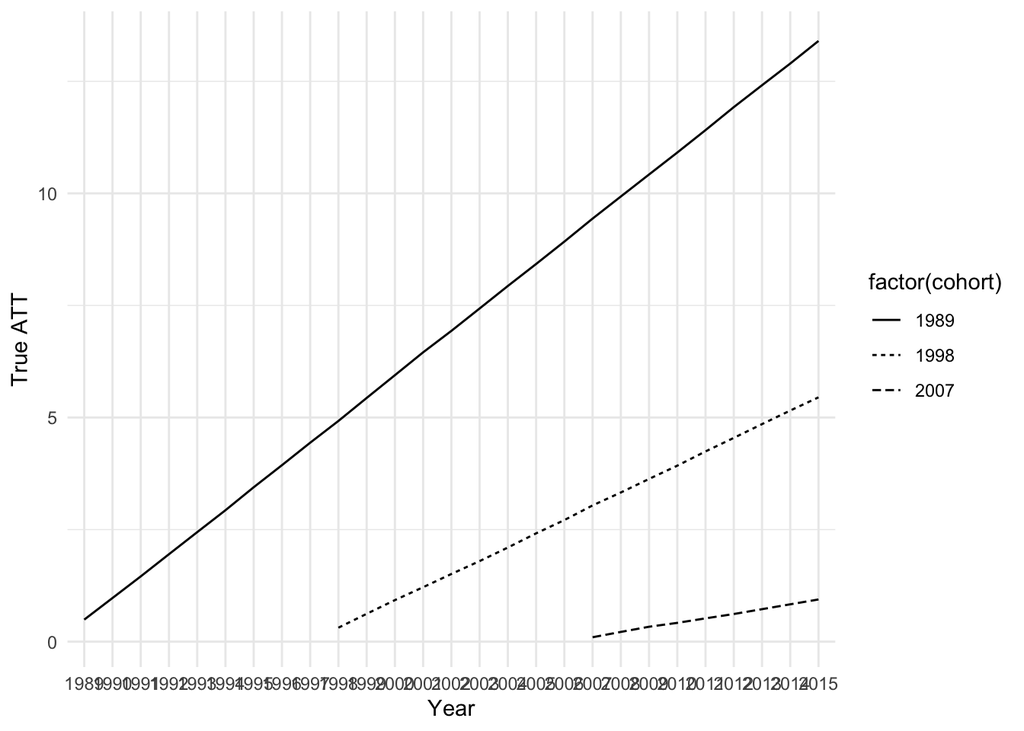

```r
# /*===========================================*/
#'=  Data Generating Process =
# /*===========================================*/
simulation6 = function() {
  dat = CJ(firm = 1:1000, year = 1980:2015)     [
    , time_fe := rnorm(1, sd = .5), by = "year"][
    , unit_fe := rnorm(1, sd = .5), by = "firm"][
    , state := sample(1:50, 1), by = "firm"    ]

  setkey(dat, state, firm, year)

  treatment_groups = data.table(
    state = c(1, 18, 35),
    cohort = c(1989, 1998, 2007),
    hat_gamma = c(.5, .3, .1))

  dat = treatment_groups[dat, roll = TRUE, on = "state"]

  dat                                                [
    , treat  := as.numeric(year >= cohort)          ][
    , gamma  := rnorm(.N, mean = hat_gamma, sd = .2)][
    , tau    := fifelse(treat == 1, gamma, 0)       ][
    , cumtau := cumsum(tau), by = "firm"            ][
    , error  := rnorm(.N, 0, .5)                    ][
    , y := unit_fe + time_fe + cumtau + error       ][
    , time_to_treat := year - cohort                ]

  return(dat)
}

dat = simulation6()


dat_true_ATT <-
  dat[treat == 1] %>%
  .[, .(att_gt = mean(cumtau)), by = .(year, cohort)]

ggplot(dat_true_ATT) +
  geom_line(
    aes(x = factor(year), y = att_gt, group = cohort, linetype = factor(cohort))
  ) +
  labs(x = "Year", y = "True ATT")
```

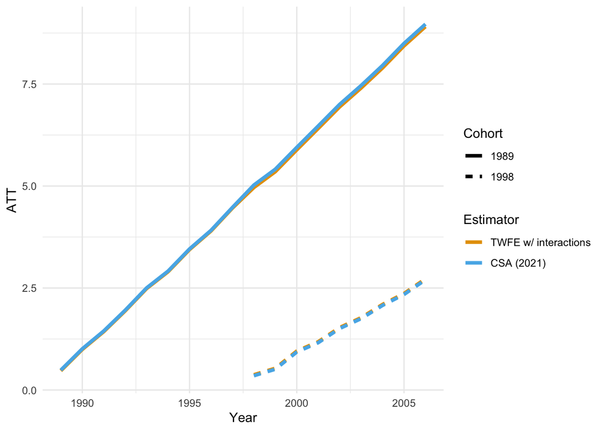

```r
# /*===========================================*/
#'=  Estimation =
# /*===========================================*/

#/*--------------------------------*/
#' ## Extended TWFE
#/*--------------------------------*/
# the treatment indicator is interacted with both time-to-treatment dummies and cohort dummies:
# dat_twfe <-
#   copy(dat) %>%
#   .[, `:=`(
#     cohort = relevel(as.factor(cohort), ref = "1989"),
#     year = relevel(as.factor(year),  ref = "1980")
#   )]

etwfe1 =
  # feols(y ~ treat : factor(time_to_treat) : factor(cohort) | firm + year, data = dat) %>%
  # same as
  feols(y ~ treat : factor(year) : factor(cohort) | firm + year, data = dat) %>%
  tidy() %>%
  data.table()

res_etwfe1 =
  etwfe1[, .(term = term, etwfe = estimate)] %>%
  .[, cohort := as.numeric(gsub(".*cohort.", "", term))] %>%
  .[, year := as.numeric(gsub(".*year\\).*?(\\d+):.*", "\\1", term))] %>%
  .[, .(cohort, year, etwfe)]


etwfe2 <-
  lm(y ~ factor(year) + factor(cohort) + factor(year):factor(cohort),
    data = dat[1989 <= year]) %>%
  tidy() %>%
  data.table()

# res_etwfe2 =
#   etwfe2[, .(term = term, etwfe2 = estimate)] %>%
#   .[, cohort := as.numeric(gsub(".*cohort.", "", term))] %>%
#   .[, year := as.numeric(gsub(".*year.(\\d+).*", "\\1", term))] %>%
#   .[cohort <= year] %>%
#   .[, .(cohort, year, etwfe2)]


# etwfe3 <-
#   etwfe(
#     fml  = y ~ 1, # outcome ~ controls
#     tvar = year,        # time variable
#     gvar = cohort, # group variable
#     data = dat,       # dataset
#   ) %>%
#   tidy() %>%
#   data.table()

# res_etwfe3 <-
#   etwfe3[, .(term = term, etwfe3 = estimate)] %>%
#   .[, cohort := as.numeric(gsub(".*cohort::(\\d+):.*", "\\1", x))] %>%
#   .[, year := as.numeric(gsub(".*year::(\\d+)", "\\1", term))] %>%
#   .[, .(cohort, year, etwfe3)]


# res_etwfe <-
#   merge(
#     res_etwfe1, res_etwfe2, by = c("cohort", "year"), all = TRUE
#   )
  # merge(., res_etwfe3, by = c("cohort", "year"), all = TRUE)


#/*--------------------------------*/
#' ## Callaway and Sant'Anna (2021)
#/*--------------------------------*/
csa = att_gt(
    yname = "y",
    gname = "cohort",
    idname = "firm",
    tname = "year",
    control_group = "notyettreated",
    data = dat)

# Clean the results
res_csa = with(csa, data.table(cohort = group, year = t, csa = att))


#/*--------------------------------*/
#' ## Merge the TWFE and CSA results
#/*--------------------------------*/
results = merge(res_etwfe1, res_csa, by = c("cohort", "year"))
colnames(results) = c("Cohort", "Year", "TWFE w/ interactions", "CSA (2021)")
results[, Cohort := factor(Cohort)]

dat_plot = melt(results, id.vars = c("Cohort", "Year"))
ggplot(dat_plot, aes(Year, value, color = variable, linetype = Cohort)) +
  geom_line(linewidth = 1.4) +
  theme_minimal() +
  labs(x = "Year", y = "ATT", color = "Estimator", linetype = "Cohort")
```

# 5 Wooldridge’s Simulation

- N = 500, T = 6 (2001 - 2006)
  - Staggered entry starts from q = 4. Therfore, there are three cohorts (2004, 2005, 2006) and never-treated group.
  - I want to estimate ATT(g,t) for each combination of post treatment periods ($t$) and cohort ($g$)
    - $ATT(2004, 2004), ATT(2004, 2005), ATT(2004, 2006)$
    - $ATT(2005, 2005), ATT(2005, 2006)$
    - $ATT(2006, 2006)$
- One covariate. CT imposed conditional on $x$.
- Some important variables:
  - `d`: cohort indicator ({0,4,5,6})
    - `d_4`, `d_5`, `d_6` are the cohort dummies
  - `w`: time varying treatment indicator
    - `w := d_4 * (year_2004 + year_2005 + year_2006) + d_5 * (year_2005 + year_2006) + d_6 * year_2006`
    - e.g., For 2004 cohort, `w=1` in 2004 ~ 2006, otherwise 0.

## 5.1 One time simulation

```r
n <- 500
n_t <- 6
B <- 1000

gen_wooldridge_sim6 <- function(){

  dt <-
    CJ(
      id = 1:n,
      year = 2001:c(2000 + n_t)
    ) %>%
    # Generate indicator variables for each year
    fastDummies::dummy_cols(select_columns = "year") %>%
    # Generate x0 using gamma(1,1), and compute mean by id
    .[, x0 := rgamma(.N, shape = 1, rate = 1)] %>%
    .[, x := mean(x0), by = id] %>%
    # Generate c ~ N(0,2) and keep it fixed within id
    .[, c := rnorm(1, mean = 0, sd = 2), by = id] %>%
    # Add serially uncorrelated error term (note: we'll add serial correlation later)
    .[, u := rnorm(.N, mean = 0, sd = 2)]

  # /*===== Generate treatment assignment (correlated with x) =====*/
  dt <-
    dt[, trt := as.integer(-0.5 + x / 3 + rnorm(.N, mean = 0, sd = 1) > 0)] %>%
    # Count number of treated years per id
    .[, trt_sum := sum(trt), by = id] %>%
    # Define treatment cohort indicators
    .[, d := fcase(
      trt_sum <= 2, 0,
      trt_sum == 3, 4,
      trt_sum == 4, 5,
      trt_sum >= 5, 6
    )] %>%
    .[, d:= factor(d, levels = c("0", "4", "5", "6"))] %>%
    fastDummies::dummy_cols(select_columns = "d") %>% # cohort dummies
    # for CS estimation
    .[, first_treat := fcase(
      d_4 == 1, 2004,
      d_5 == 1, 2005,
      d_6 == 1, 2006,
      default = 0
    )] %>%
    # Drop intermediate treatment variables
    .[, c("trt", "trt_sum") := NULL]

  # /*===== Generate potential outcomes with common trends imposed. =====*/
  # * Also common effect across time.
  dt[, yinf := 20 + 0.2 * year_2002 + 0.3 * year_2003 + 0.4 * year_2004 + 0.5 * year_2005 + 0.6 * year_2006 + x/2 + c - (year_2004 + year_2005 + year_2006) + u
    ] %>%
    # Create y4, y5, y6 based on yinf and apply modifications conditional on year
    .[, c("y4", "y5", "y6") := yinf] %>%
    .[year >= 2004, y4 := 4 + yinf + (x - 1)/3 + 0.2 * year_2005 + 0.6 * year_2006 + rnorm(.N, mean = 0, sd = 2)] %>%
    .[year >= 2005, y5 := 3 + yinf + (x - 1)/4 + 0.6 * year_2006 + rnorm(.N, mean = 0, sd = 2)] %>%
    .[year >= 2006, y6 := 2 + yinf + (x - 1)/5 + rnorm(.N, mean = 0, sd = 2)]

  # /*===== Generate Observed Outcome =====*/
  # Generate observed outcome based on treatment cohort
  dt[, y := d_0 * yinf + d_4 * y4 + d_5 * y5 + d_6 * y6]

  # Generate time-varying treatment indicator for staggered intervention (w = d * p)
  dt[, w := d_4 * (year_2004 + year_2005 + year_2006) + d_5 * (year_2005 + year_2006) + d_6 * year_2006]

  # /*===== Demean x by corhort =====*/
  mean_x_d_4 <- dt[d_4 == 1, mean(x)]
  dt[, x_dm4 := x - mean_x_d_4]
  mean_x_d_5 <- dt[d_5 == 1, mean(x)]
  dt[, x_dm5 := x - mean_x_d_5]
  mean_x_d_6 <- dt[d_6 == 1, mean(x)]
  dt[, x_dm6 := x - mean_x_d_6]

  # for(d in c("4", "5", "6")) {
  #   dt[, paste0("x_dm", d) := x - dt[get(paste0("d_", d)) == 1, mean(x)]]
  # }

  # /*===== True ATT(g,t) =====*/
  true_att <-
    dt[first_treat > 0 & year >= first_treat,] %>%
    .[,true_att := fcase(
      d_4 == 1, y4 - yinf,
      d_5 == 1, y5 - yinf,
      d_6 == 1, y6 - yinf
    )] %>%
    .[first_treat > 0 & year >= first_treat, .(att_gt = mean(true_att, na.rm = TRUE)),
    by = .(cohort = first_treat, year)
    ]

  return(list(dt = dt,  true_att = true_att))
}


set.seed(123)
ls_dt <- gen_wooldridge_sim6()
dt <- ls_dt$dt
true_att <- ls_dt$true_att
```

### 5.1.1 Without Controls

Following models are equivalent: TWM model (1.1) - Full time period dummies
$$y_{it} \text{ on } 1, d_{iq}, ..., d_{iT}, f2_t, ..., fT_t, d_{iq}\cdot fq_t, d_{iq}\cdot fT_t, ..., d_{iT} \cdot fT_t$$

TWM model (1.2) - Time period dummies after the treatment (post-treatment time period dummies)
$$y_{it} \text{ on } 1, d_{iq}, ..., d_{iT}, f2_t, ..., fT_t, d_{iq}\cdot fq_t, ..., d_{iq}\cdot fT_t, ..., d_{iT} \cdot fT_t$$

ETWFE model (1.3)
$$y_{it} \text{ on } 1, d_{iq}, ..., d_{iT}, f2_t, ..., fT_t, d_{iq}\cdot fq_t, d_{iq}\cdot fT_t, ..., d_{iT} \cdot fT_t$$

Note that TWM model (1.1) can be written as the follwoing TWM model (1.2.1) which is shown in Equation (6.16) in the paper.

TWM model (1.2.1)
$$y_{it} \text{ on } 1, d_{iq}, ..., d_{iT}, f2_t, ..., fT_t, w_{it} \cdot d_{iq}\cdot fq_t, ..., w_{it} \cdot d_{iq}\cdot fT_t, ..., w_{it} \cdot d_{iT} \cdot fT_t$$

Why $w_{it} \cdot d_{ir}\cdot fs_t = d_{ir}\cdot fs_t$ for $s \ge r$, $r \in \{q, q+1, ..., T\}$? This is simple. $w_{it}$ indicates treatment status for individual $i$ at time period $t$. For example, $w_{ir}=1$ when individual $i$ is in post-treatment status after $t \ge r$. Meanwhile, $d_{ir}\cdot fs_t = 1$ only when individual $i$ is in treatment cohort $r$ and he is in post-treatment time period. Therefore, whenever $d_{ir}\cdot fs_t = 1$, $w_{it} = 1$ ($d_{ir}\cdot fs_t = 1$ and $w_[it]$ moves exactly in the same way). Thus, $w_{it} \cdot d_{ir}\cdot fs_t = d_{ir}\cdot fs_t$ for $s \ge r$, $r \in \{q, q+1, ..., T\}$.

Wooldridge show the Equation (6.16) to emphasize that the model can allow fir substantial effect heterogeneity beyond the approach taht includes only $w_{it}$ by itself and estimate a single treatment effect.

```r
# /*===========================================*/
#'=  Without Controls =
# /*===========================================*/
# /*===== (1.1) POLS, TWM, Equation (6.17) in the paper  =====*/
# Full year dummies
run_reg_no_controls <- function(dt){
twm1_1 <-
  feols(y ~
    d_4 + d_5 + d_6 +
    factor(year) +
    d_4:year_2004 + d_4:year_2005 + d_4:year_2006 +
    d_5:year_2005 + d_5:year_2006 +
    d_6:year_2006,
    cluster = ~id, data = dt
  ) %>%
  tidy() %>%
  data.table() %>%
  .[grepl("^d_[0-9]+:year_[0-9]+$", term)] %>%
  .[, `:=`(
    year = as.numeric(gsub(".*year_([0-9]+).*", "\\1", term)),
    cohort = as.numeric(gsub(".*d_([0-9]+).*", "\\1", term)) + 2000
  )] %>%
  .[, .(cohort, year, estimate, std.error)] %>%
  .[, `:=`(model = "pols1",controls = "no")]

# /*===== (1.2) POLS, TWM, Equation (6.17)=====*/
# "the time period dummies prior to q can be dropped without affecting the estimates"
twm1_2 <-
  feols(
    y ~
    d_4 + d_5 + d_6 +
    year_2004 + year_2005 + year_2006 +
    d_4:year_2004 + d_4:year_2005 + d_4:year_2006 +
    d_5:year_2005 + d_5:year_2006 +
    d_6:year_2006,
    cluster = ~id, data = dt
  ) %>%
  tidy() %>%
  data.table() %>%
  .[grepl("^d_[0-9]+:year_[0-9]+$", term)] %>%
  .[, `:=`(
    year = as.numeric(gsub(".*year_([0-9]+).*", "\\1", term)),
    cohort = as.numeric(gsub(".*d_([0-9]+).*", "\\1", term)) + 2000
  )] %>%
  .[, .(cohort, year, estimate, std.error)] %>%
  .[, `:=`(model = "twm",controls = "no")]

# This is equivalent to:
# twm1_2_1 <-
#   feols(
#     y ~
#     d_4 + d_5 + d_6 +
#     year_2004 + year_2005 + year_2006 +
#     w:d_4:year_2004 + w:d_4:year_2005 + w:d_4:year_2006 +
#     w:d_5:year_2005 + w:d_5:year_2006 +
#     w:d_6:year_2006,
#     cluster = ~id, data = dt
#   ) %>%
#   tidy() %>%
#   data.table() %>%
#   .[grepl("^d_[0-9]+:year_[0-9]+:w$", term)] %>%
#   .[, `:=`(
#     year = as.numeric(gsub(".*year_([0-9]+).*", "\\1", term)),
#     cohort = as.numeric(gsub(".*d_([0-9]+).*", "\\1", term)) + 2000
#   )] %>%
#   .[, .(cohort, year, estimate, std.error)] %>%
#   .[, `:=`(model = "twm2",controls = "no")]



# /*===== (1.3) TWFE =====*/
# TWFE
twfe1_3 <-
  feols(y ~
    d_4:year_2004 + d_4:year_2005 + d_4:year_2006 +
    d_5:year_2005 + d_5:year_2006 +
    d_6:year_2006 | id + year,
    cluster = ~id, data = dt
  ) %>%
  tidy() %>%
  data.table() %>%
  .[, `:=`(
    year = as.numeric(gsub(".*year_([0-9]+).*", "\\1", term)),
    cohort = as.numeric(gsub(".*d_([0-9]+).*", "\\1", term)) + 2000
  )] %>%
  .[, .(cohort, year, estimate, std.error)] %>%
  .[, `:=`(model = "etwfe",controls = "no")]

# /*===== (1.4) CS-DID =====*/
cs_1_4 <-
  att_gt(
    yname = "y",
    gname = "first_treat",
    idname = "id",
    tname = "year",
    # control_group = "notyettreated",
    control_group =c("nevertreated", "notyettreated"),
    est_method = "dr",
    clustervars = "id",
    data = dt
  ) %>%
  tidy() %>%
  data.table() %>%
  .[, .(cohort = group, year = time, estimate, std.error)] %>%
  .[cohort <= year,] %>%
  .[, `:=`(model = "cs",controls = "no")]

  reg_res1 <- rbindlist(list(twm1_2, twfe1_3, cs_1_4))

  return(reg_res1)
}

reg_res1 <- run_reg_no_controls(dt)

reg_res1
```

```
    cohort  year estimate std.error  model controls
     <num> <num>    <num>     <num> <char>   <char>
 1:   2004  2004 4.445553 0.2624270    twm       no
 2:   2004  2005 4.018169 0.2628984    twm       no
 3:   2004  2006 4.534202 0.2920090    twm       no
 4:   2005  2005 3.310856 0.3410794    twm       no
 5:   2005  2006 3.051551 0.3353305    twm       no
 6:   2006  2006 2.252421 0.4252562    twm       no
 7:   2004  2004 4.445553 0.2623831  etwfe       no
 8:   2004  2005 4.018169 0.2628544  etwfe       no
 9:   2004  2006 4.534202 0.2919602  etwfe       no
10:   2005  2005 3.310856 0.3410223  etwfe       no
11:   2005  2006 3.051551 0.3352744  etwfe       no
12:   2006  2006 2.252421 0.4251850  etwfe       no
13:   2004  2004 4.292435 0.3610842     cs       no
14:   2004  2005 3.886689 0.3054743     cs       no
15:   2004  2006 4.347710 0.3540125     cs       no
16:   2005  2005 3.454909 0.4022008     cs       no
17:   2005  2006 3.140593 0.3874908     cs       no
18:   2006  2006 1.857910 0.5227657     cs       no
```

**Important**

**Caution**

Note that coefficient estimates between ETWFE (TWM) and CS-DID are not exactly the same. This is because I simply run regressions one time. If we run the simulation many times, the average estimates will be the same.

### 5.1.2 With Controls

- As a result of theorem 3.2, additing time-constant controls $x_i$, and also interacting them with the cohort dummies $d_{ir}$ does not change the treatment effect estimates. > “However, having access to covariates allows us to relax the common trends assumption even in the staggered case.”

```r
# /*===========================================*/
#'=  With controls  =
# /*===========================================*/
# /*===== (2.1) POLS, TWM, Equation (6.25) in the paper =====*/
run_reg_controls <- function(dt){
twm2_1 <-
  feols(
  y ~
    d_4 + d_5 + d_6 +
    x +
    d_4:x + d_5:x + d_6:x +
    year_2004 + year_2005 + year_2006 +
    year_2004:x + year_2005:x + year_2006:x +
    # w * d * f
    d_4:year_2004 + d_4:year_2005 + d_4:year_2006 +
    d_5:year_2005 + d_5:year_2006 +
    d_6:year_2006 +
    # w * d * f * demeaned_x
    d_4:year_2004:x_dm4 + d_4:year_2005:x_dm4 + d_4:year_2006:x_dm4 +
    d_5:year_2005:x_dm5 + d_5:year_2006:x_dm5 +
    d_6:year_2006:x_dm6,
  cluster = ~id,
  data = dt
  ) %>%
  tidy() %>%
  data.table() %>%
  .[grepl("^d_[0-9]+:year_[0-9]+$", term)] %>%
  .[, `:=`(
    year = as.numeric(gsub(".*year_([0-9]+).*", "\\1", term)),
    cohort = as.numeric(gsub(".*d_([0-9]+).*", "\\1", term)) + 2000
  )] %>%
  .[, .(cohort, year, estimate, std.error)] %>%
  .[, `:=`(model = "twm",controls = "yes")]

# , which is equivelent to
# twm2_1_1 <-
#   feols(
#   y ~
#     d_4 + d_5 + d_6 +
#     x +
#     d_4:x + d_5:x + d_6:x +
#     year_2004 + year_2005 + year_2006 +
#     year_2004:x + year_2005:x + year_2006:x +
#     # w * d * f
#     w:d_4:year_2004 + w:d_4:year_2005 + w:d_4:year_2006 +
#     w:d_5:year_2005 + w:d_5:year_2006 +
#     w:d_6:year_2006 +
#     # w * d * f * demeaned_x
#     w:d_4:year_2004:x_dm4 + w:d_4:year_2005:x_dm4 + w:d_4:year_2006:x_dm4 +
#     w:d_5:year_2005:x_dm5 + w:d_5:year_2006:x_dm5 +
#     w:d_6:year_2006:x_dm6,
#   cluster = ~id,
#   data = dt
#   ) %>%
#   tidy() %>%
#   data.table() %>%
#   .[grepl("^d_[0-9]+:year_[0-9]+:w$", term)] %>%
#   .[, `:=`(
#     year = as.numeric(gsub(".*year_([0-9]+).*", "\\1", term)),
#     cohort = as.numeric(gsub(".*d_([0-9]+).*", "\\1", term)) + 2000
#   )] %>%
#   .[, .(cohort, year, estimate, std.error)] %>%
#   .[, `:=`(model = "twm",controls = "yes")]

# /*===== (2.2) ETWFE =====*/
etwfe2_2 <-
  feols(
    y ~
    d_4:year_2004 +d_4:year_2005 +d_4:year_2006 +
    d_5:year_2005 +d_5:year_2006 +
    d_6:year_2006 +
    d_4:year_2004:x_dm4 +d_4:year_2005:x_dm4 +d_4:year_2006:x_dm4 +
    d_5:year_2005:x_dm5 +d_5:year_2006:x_dm5 +
    d_6:year_2006:x_dm6  +
    factor(year) + factor(year):x|id,
    cluster = ~id,
    data = dt
  ) %>%
  tidy() %>%
  data.table() %>%
  .[, term := sapply(term, standardize_term)] %>%
  .[grepl("^d_[0-9]+:year_[0-9]+$", term)] %>%
  .[, `:=`(
    year = as.numeric(gsub(".*year_([0-9]+).*", "\\1", term)),
    cohort = as.numeric(gsub(".*d_([0-9]+).*", "\\1", term)) + 2000
  )] %>%
  .[, .(cohort, year, estimate, std.error)] %>%
  .[, `:=`(model = "etwfe",controls = "yes")]


# which is equivalent to
# etwfe2_2_1 <-
#   feols(
#     y ~
#     d_4:year_2004 +d_4:year_2005 +d_4:year_2006 +
#     d_5:year_2005 +d_5:year_2006 +
#     d_6:year_2006 +
#     d_4:year_2004:x_dm4 +d_4:year_2005:x_dm4 +d_4:year_2006:x_dm4 +
#     d_5:year_2005:x_dm5 +d_5:year_2006:x_dm5 +
#     d_6:year_2006:x_dm6 + factor(year):x|id + year,
#     cluster = ~id,
#     data = dt
#   ) %>%
#   tidy() %>%
#   data.table() %>%
#   .[, term := sapply(term, standardize_term)] %>%
#   .[grepl("^d_[0-9]+:year_[0-9]+$", term)] %>%
#   .[, `:=`(
#     year = as.numeric(gsub(".*year_([0-9]+).*", "\\1", term)),
#     cohort = as.numeric(gsub(".*d_([0-9]+).*", "\\1", term)) + 2000
#   )] %>%
#   .[, .(cohort, year, estimate, std.error)] %>%
#   .[, `:=`(model = "etwfe",controls = "yes")]

# test_etwfe <-
#   etwfe(
#     fml  = y ~ x, # outcome ~ controls
#     tvar = year,        # time variable
#     gvar = first_treat, # group variable
#     data = dt,       # dataset
#     vcov = ~id  # vcov adjustment (here: clustered)
#   ) %>%
#   tidy() %>%
#   data.table() %>%
#   .[grepl("^\\.Dtreat:first_treat::[0-9]{4}:year::[0-9]{4}$", term)] %>%
#   .[, `:=`(
#     year = as.numeric(gsub(".*year::([0-9]+).*", "\\1", term)),
#     cohort = as.numeric(gsub(".*first_treat::([0-9]+).*", "\\1", term))
#   )] %>%
#   .[, .(cohort, year, estimate, std.error)] %>%
#   .[, `:=`(model = "etwfe",controls = "yes")]

# /*===== (2.3) CS-DID =====*/
cs_2_3 <-
  att_gt(
    yname = "y",
    gname = "first_treat",
    idname = "id",
    tname = "year",
    xformla = ~ x,
    control_group =c("nevertreated", "notyettreated"),
    est_method = "dr",
    clustervars = "id",
    data = dt
  ) %>%
  tidy() %>%
  data.table() %>%
  .[, .(cohort = group, year = time, estimate, std.error)] %>%
  .[cohort <= year,] %>%
  .[, `:=`(model = "cs",controls = "yes")]

reg_res2 <- rbindlist(list(twm2_1, etwfe2_2, cs_2_3))

return(reg_res2)

}

reg_res2 <- run_reg_controls(dt)

true_att
```

```
   cohort  year   att_gt
    <num> <int>    <num>
1:   2004  2004 3.967447
2:   2004  2005 4.012741
3:   2004  2006 4.592898
4:   2005  2005 3.230046
5:   2005  2006 3.431723
6:   2006  2006 2.250148
```

```r
reg_res2
```

```
    cohort  year estimate std.error  model controls
     <num> <num>    <num>     <num> <char>   <char>
 1:   2004  2004 4.437085 0.2627113    twm      yes
 2:   2004  2005 3.996034 0.2699863    twm      yes
 3:   2004  2006 4.539372 0.2980078    twm      yes
 4:   2005  2005 3.266729 0.3612585    twm      yes
 5:   2005  2006 3.063332 0.3554431    twm      yes
 6:   2006  2006 2.277932 0.4342842    twm      yes
 7:   2004  2004 4.437085 0.2625789  etwfe      yes
 8:   2004  2005 3.996034 0.2698503  etwfe      yes
 9:   2004  2006 4.539372 0.2978576  etwfe      yes
10:   2005  2005 3.266729 0.3610764  etwfe      yes
11:   2005  2006 3.063332 0.3552640  etwfe      yes
12:   2006  2006 2.277932 0.4340653  etwfe      yes
13:   2004  2004 4.269741 0.3879473     cs      yes
14:   2004  2005 3.842788 0.3543165     cs      yes
15:   2004  2006 4.346056 0.3766261     cs      yes
16:   2005  2005 3.292753 0.4974412     cs      yes
17:   2005  2006 3.122019 0.4321319     cs      yes
18:   2006  2006 2.053795 0.5449969     cs      yes
```

## 5.2 Wooldridge’s Simulations: Run 1000 times

```r
set.seed(1234)

res_sim_sim6  <-
  mclapply(
    1:1000,
    \(i){
      ls_dt <- gen_wooldridge_sim6()
      dt <- ls_dt$dt
      true_att <- ls_dt$true_att

      reg_res_all <-
        rbind(
          run_reg_no_controls(dt),
          run_reg_controls(dt)
        ) %>%
        .[, sim := i]

      return(list(
        reg_res_all = reg_res_all,
        true_att = true_att
      ))
    },
    mc.cores = 10
  )

res_sim6_reg <-
  lapply(res_sim_sim6, \(x) x$reg_res_all) %>%
  rbindlist() %>%
  .[, .(
    estimate = mean(estimate),
    sd = sd(estimate)
  ), by = .(cohort, year, model, controls)]

res_sim6_true_att <-
  lapply(res_sim_sim6, \(x) x$true_att) %>%
  rbindlist() %>%
  .[, .(att_gt = mean(att_gt)), by = .(cohort, year)]

res_sim6_reg_combined <-
  merge(res_sim6_reg, res_sim6_true_att, by = c("cohort", "year")) %>%
  .[, c("att_gt", "estimate", "sd") := lapply(.SD, round, 2), .SDcols = c("att_gt", "estimate", "sd")]

tb_res_sim6_no_controls <-
  res_sim6_reg_combined[controls == "no"] %>%
  dcast(cohort + year + controls + att_gt~ model, value.var = c("estimate", "sd")) %>%
  .[,.(cohort, year, controls, att_gt, estimate_twm, sd_twm, estimate_etwfe, sd_etwfe, estimate_cs, sd_cs)] %>%
  .[, c("cohort", "year") := lapply(.SD, as.character), .SDcols = c("cohort", "year")]


tb_res_sim6_controls <-
  res_sim6_reg_combined[controls == "yes"] %>%
  dcast(cohort + year + controls + att_gt~ model, value.var = c("estimate", "sd")) %>%
  .[,.(cohort, year, controls, att_gt, estimate_twm, sd_twm, estimate_etwfe, sd_etwfe, estimate_cs, sd_cs)] %>%
  .[, c("cohort", "year") := lapply(.SD, as.character), .SDcols = c("cohort", "year")]
```

```r
flextable(tb_res_sim6_no_controls)
```

| cohort | year | controls | att_gt | estimate_twm | sd_twm | estimate_etwfe | sd_etwfe | estimate_cs | sd_cs |
| --- | --- | --- | --- | --- | --- | --- | --- | --- | --- |
| 2004 | 2004 | no | 4.01 | 4.01 | 0.27 | 4.01 | 0.27 | 4.02 | 0.33 |
| 2004 | 2005 | no | 4.20 | 4.20 | 0.29 | 4.20 | 0.29 | 4.21 | 0.35 |
| 2004 | 2006 | no | 4.61 | 4.61 | 0.28 | 4.61 | 0.28 | 4.61 | 0.33 |
| 2005 | 2005 | no | 3.02 | 3.02 | 0.36 | 3.02 | 0.36 | 3.03 | 0.41 |
| 2005 | 2006 | no | 3.63 | 3.63 | 0.36 | 3.63 | 0.36 | 3.64 | 0.42 |
| 2006 | 2006 | no | 2.06 | 2.08 | 0.54 | 2.08 | 0.54 | 2.08 | 0.64 |

```r
flextable(tb_res_sim6_controls)
```

| cohort | year | controls | att_gt | estimate_twm | sd_twm | estimate_etwfe | sd_etwfe | estimate_cs | sd_cs |
| --- | --- | --- | --- | --- | --- | --- | --- | --- | --- |
| 2004 | 2004 | yes | 4.01 | 4.01 | 0.27 | 4.01 | 0.27 | 4.02 | 0.34 |
| 2004 | 2005 | yes | 4.20 | 4.20 | 0.29 | 4.20 | 0.29 | 4.21 | 0.36 |
| 2004 | 2006 | yes | 4.61 | 4.61 | 0.29 | 4.61 | 0.29 | 4.61 | 0.34 |
| 2005 | 2005 | yes | 3.02 | 3.02 | 0.36 | 3.02 | 0.36 | 3.03 | 0.43 |
| 2005 | 2006 | yes | 3.63 | 3.63 | 0.36 | 3.63 | 0.36 | 3.64 | 0.43 |
| 2006 | 2006 | yes | 2.06 | 2.08 | 0.56 | 2.08 | 0.56 | 2.08 | 0.67 |

# 6 Outdated

## 6.1 The Baker simulation

```r
set.seed(20200403)
# /*===========================================*/
#'=  Data Generating Process =
# /*===========================================*/
# /*===== Fixed Effects =====*/
# unit fixed effects
unit <-
  data.table(
    unit = 1:1000,
    unit_fe = rnorm(1000, 0, 1),
    # generate state
    state = sample(1:40, 1000, replace = TRUE),
    # generate treatment effect
    mu = rnorm(1000, 0.3, 0.2)
  )

# year fixed effects
year <-
  data.table(
    year = 1980:2010,
    year_fe = rnorm(31, 0, 1)
  )

# /*===== Trend Break =====*/
# Put the states into treatment groups
treat_taus <- data.table(
  # sample the states randomly
  state = sample(1:40, 40, replace = FALSE),
  # place the randomly sampled states into five treatment groups G_g
  cohort = sort(rep(c(1982, 1991, 1998, 2004), 10))
  )

# make main dataset
# full interaction of unit X year
dat <-
  CJ(unit = 1:1000, year = 1980:2010) %>%
  merge(., unit, by = "unit", all.x = TRUE) %>%
  merge(., year, by = "year", all.x = TRUE) %>%
  merge(., treat_taus, by = "state", all.x = TRUE)
  # make error term and get treatment indicators and treatment effects

setkey(dat, state, unit, year)

dat <-
  dat %>%
  .[, error := rnorm(31000, 0, 0.5)] %>%
  .[, treat := ifelse(year >= cohort, 1, 0)] %>%
  .[, time_to_treat := year - cohort] %>%
  .[, tau := ifelse(treat == 1, mu, 0)] %>%
  # calculate cumulative treatment effects
  .[, cumtau := cumsum(tau), by = unit] %>%
  # calculate the dep variable
  .[, dep_var := unit_fe + year_fe + cumtau + error]


dat_true_ATT <-
  dat[treat == 1] %>%
  .[, .(att_gt = mean(cumtau)), by = .(year, cohort)] %>%
  .[, time_to_treat := year - cohort]

ggplot(dat_true_ATT) +
  geom_line(
    aes(x = factor(year), y = att_gt, group = cohort, linetype = factor(cohort))
  ) +
  labs(x = "Year", y = "True ATT")

# /*===========================================*/
#'=  Estimation =
# /*===========================================*/
#/*--------------------------------*/
#' ## Extended TWFE
#/*--------------------------------*/
# mod <- feols(dep_var ~ treat : i(cohort, i.year) + i(year) | unit, data = dat)

mod <-
  feols(dep_var ~ treat : factor(time_to_treat) : factor(cohort) |unit + year, data = dat) %>%
  tidy(., conf.int = TRUE) %>%
  data.table()

cohorts <- c(as.character(sort(unique(dat$cohort))), NA)

res_mod <-
  mod %>%
  # ignore year dummies
  # .[grepl("^w", term)] %>%
  # cleanup
  .[, cohort := as.numeric(gsub(".*cohort.", "", term))] %>%
  .[, year := as.numeric(gsub(".*time_to_treat.(\\d+).*", "\\1", term)) + cohort]

  # .[, `:=`(
  #   cohort = as.numeric(sub(".*cohort::(\\d+).*", "\\1", term)),
  #   year = as.numeric(sub(".*year::(\\d+).*", "\\1", term))
  # )] %>%
  # .[, time_to_treatment := year - cohort] %>%
  # .[, cohort_next := as.numeric(cohorts[match(as.character(cohort), cohorts) + 1])] %>%
  # .[year < cohort_next]

ggplot(
  res_mod,
  aes(x = year, y = estimate, ymin = conf.low, ymax = conf.high, color = factor(cohort))
  ) +
  # Baker simulation:
  # tau is a random variable equal with mean 0.3
  # cumsum(tau) = ATT
  geom_abline(intercept = .3, slope = .3) +
  geom_pointrange() +
  labs(
    x = "Year",
    y = "ATT",
    color = "Cohort",
    title = "Group-Time ATTs estimated using TWFE & Interactions.",
    subtitle = "The black line shows the truth."
  )
```

[output not shown]

## References

Wooldridge, Jeffrey M. 2021. “Two-Way Fixed Effects, the Two-Way Mundlak Regression, and Difference-in-Differences Estimators.” {{SSRN Scholarly Paper}}. Rochester, NY: Social Science Research Network. https://doi.org/10.2139/ssrn.3906345.